# Introduction

**Module 01** GESIS Fall Seminar “Introduction to Computational Social Science”

Johannes B. Gruber

GESIS

John McLevey

University of Waterloo

## Schedule: GESIS Fall Seminar in Computational Social Science

Course Schedule

| time | Session |
| --- | --- |
| **Day 1** | **Introduction to Computational Social Science** |
| Day 2 | Obtaining Data |
| Day 3 | Computational Network Analysis |
| Day 4 | Computational Text Analysis |
| Day 5 | Large Language Models in the Social Sciences |

## Who is Johannes?

- Senior Researcher/Team Lead in *Data Services for the Social Sciences* @ GESIS
- Previously PostDoc in Communication at VU Amsterdam, University of Amsterdam, and European New School of Digital Studies
- Interested in:
  - Computational Social Science
  - Data Quality
  - Open and reproducible science
  - Automated Content Analysis
  - Hybrid Media Systems and Information Flows
  - Protest and Democracy
- Experience:
  - R user since 2015
  - R package developer since 2017
  - Worked on several packages for text analysis, API access and web scraping (spacyr, quanteda.textmodels, LexisNexisTools, paperboy, traktok, rollama, amcat4-r, atrrr, rwhatsapp and more)

Contact:

- [@jbgruber.bsky.social](https://bsky.app/profile/jbgruber.bsky.social)
- [@JohannesBGruber](https://twitter.com/JohannesBGruber)

## Who is John?

John McLevey (he / him)  
Associate Professor, University of Waterloo  
PI, Computational Social Science Lab

I first got into computational social science via natural language processing and probabilistic topic modelling as a PhD student ~ 2009.

Within computational social science, my interests and expertise are primarily in network science, computational text analysis, generative modelling, bayesian data analysis, causal inference, and scientific computing. I also work in cognitive social science, political sociology, sociology of science, and environmental sociology.

[figure not shown]

## What is computational social science?

> “Anything that’s cool.”  
> - [Matt Salganik](https://www.princeton.edu/~mjs3/) (Author of [Bit by Bit](https://www.bitbybitbook.com))

Computational social science is diverse and multi-paradigmatic

- often involves working with “found” / “readymade” data (Salganik 2019)
- often employs machine learning frameworks, computational experiments, and/or *generative* models (Edelmann et al. 2020; Centola 2018; Bail 2022; McElreath 2018; Grimmer, Roberts, and Stewart 2022; Kitts, Grogan, and Lewis 2023; Smaldino 2023)
- involves difficult interpretative work (Grigoropoulou and Small 2022; Nelson 2020)
- generally requires scientific computing and software development skills to develop data processing and modelling *pipelines* (Atteveldt, Trilling, and Arcíla 2021; McLevey 2022; McLevey, Browne, and Crick 2021)
- should meet a higher bar for privacy protection, research ethics, transparency, and accountability (O’Neil 2017)
- is computational **and** social scientific

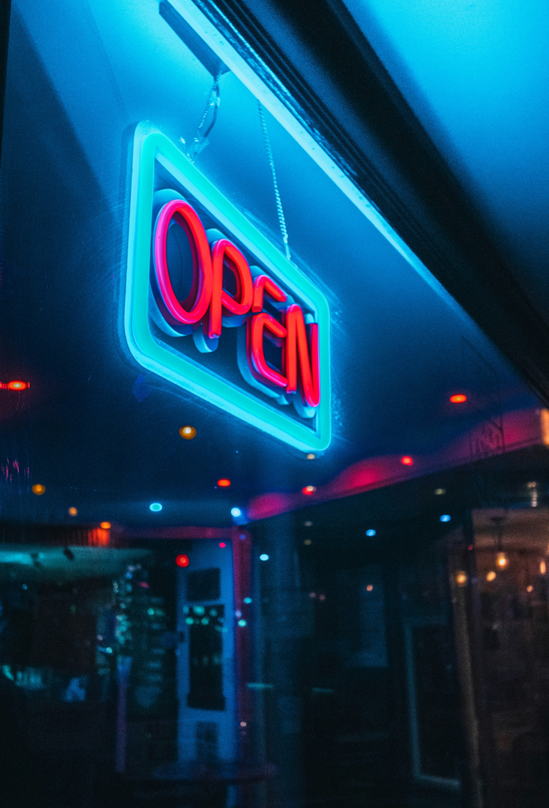

Photo by [Super Straho](https://unsplash.com/@superstraho?utm_content=creditCopyText&utm_medium=referral&utm_source=unsplash) on [Unsplash](https://unsplash.com/photos/purple-and-pink-love-neon-light-signage-CPtKXzwGKiw?utm_content=creditCopyText&utm_medium=referral&utm_source=unsplash)

# Exploratory Data Analysis

## The process

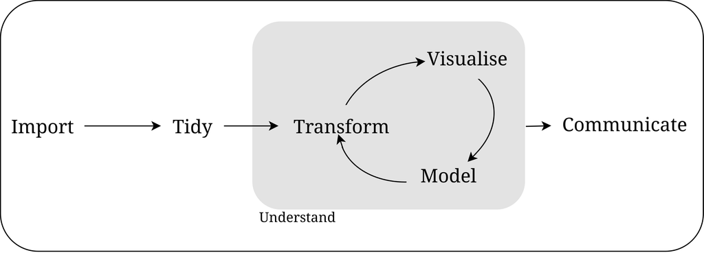

Source: Wickham, Çetinkaya-Rundel, and Grolemund (2023)

- “Data science is the process by which data becomes understanding, knowledge and insight”–Hadley Wickham
- “You can’t do data science in a GUI”–Hadley Wickham

## The steps

1. Generate questions about your data.
2. Search for answers by visualising, transforming, and modelling your data.
3. Use what you learn to refine your questions and/or generate new questions.

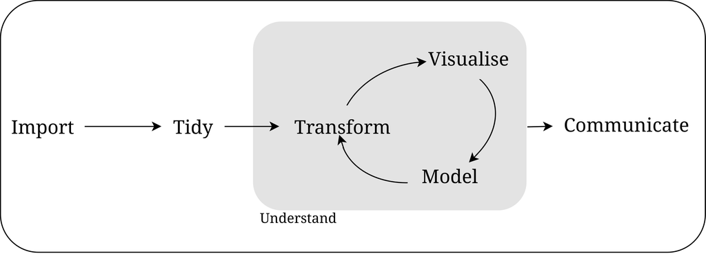

# CSS Examples

## Sounding the alarm based COVID numbers

[figure not shown]

## Trump’s tweets

Data from http://varianceexplained.org:

```
Rows: 1,512
Columns: 16
$ text          <chr> "My economic policy speech will be carried live at 12:15 P.M. Enjoy!", "Join me in Fayetteville, North Carolina tomorrow evening at 6pm. Tickets n…
$ favorited     <lgl> FALSE, FALSE, FALSE, FALSE, FALSE, FALSE, FALSE, FALSE, FALSE, FALSE, FALSE, FALSE, FALSE, FALSE, FALSE, FALSE, FALSE, FALSE, FALSE, FALSE, FALSE,…
$ favoriteCount <dbl> 9214, 6981, 15724, 19837, 34051, 29831, 19223, 19543, 75488, 23661, 28069, 35205, 36936, 32716, 34109, 19436, 19330, 30869, 19431, 27568, 25860, 2…
$ replyToSN     <chr> NA, NA, NA, NA, NA, NA, NA, NA, NA, NA, NA, NA, NA, NA, NA, NA, NA, NA, NA, NA, NA, NA, NA, NA, NA, NA, NA, NA, NA, NA, NA, NA, NA, NA, NA, NA, NA…
$ created       <dttm> 2016-08-08 15:20:44, 2016-08-08 13:28:20, 2016-08-08 00:05:54, 2016-08-07 23:09:08, 2016-08-07 21:31:46, 2016-08-07 13:49:29, 2016-08-07 02:19:37…
$ truncated     <lgl> FALSE, FALSE, FALSE, FALSE, FALSE, FALSE, FALSE, FALSE, FALSE, FALSE, FALSE, FALSE, FALSE, FALSE, FALSE, FALSE, FALSE, FALSE, FALSE, FALSE, FALSE,…
$ replyToSID    <lgl> NA, NA, NA, NA, NA, NA, NA, NA, NA, NA, NA, NA, NA, NA, NA, NA, NA, NA, NA, NA, NA, NA, NA, NA, NA, NA, NA, NA, NA, NA, NA, NA, NA, NA, NA, NA, NA…
$ id            <chr> "762669882571980801", "762641595439190016", "762439658911338496", "762425371874557952", "762400869858115588", "762284533341417472", "7621109187213…
$ replyToUID    <chr> NA, NA, NA, NA, NA, NA, NA, NA, NA, NA, NA, NA, NA, NA, NA, NA, NA, NA, NA, NA, NA, NA, NA, NA, NA, NA, NA, NA, NA, NA, NA, NA, NA, NA, NA, NA, NA…
$ statusSource  <chr> "<a href=\"http://twitter.com/download/android\" rel=\"nofollow\">Twitter for Android</a>", "<a href=\"http://twitter.com/download/iphone\" rel=\"…
$ screenName    <chr> "realDonaldTrump", "realDonaldTrump", "realDonaldTrump", "realDonaldTrump", "realDonaldTrump", "realDonaldTrump", "realDonaldTrump", "realDonaldTr…
$ retweetCount  <dbl> 3107, 2390, 6691, 6402, 11717, 9892, 5784, 7930, 24663, 7903, 8561, 13129, 13250, 9356, 10385, 8066, 5418, 16786, 5681, 13869, 8989, 8674, 12351, …
$ isRetweet     <lgl> FALSE, FALSE, FALSE, FALSE, FALSE, FALSE, FALSE, FALSE, FALSE, FALSE, FALSE, FALSE, FALSE, FALSE, FALSE, FALSE, FALSE, FALSE, FALSE, FALSE, FALSE,…
$ retweeted     <lgl> FALSE, FALSE, FALSE, FALSE, FALSE, FALSE, FALSE, FALSE, FALSE, FALSE, FALSE, FALSE, FALSE, FALSE, FALSE, FALSE, FALSE, FALSE, FALSE, FALSE, FALSE,…
$ longitude     <chr> NA, NA, NA, NA, NA, NA, NA, NA, NA, NA, NA, NA, NA, NA, NA, NA, NA, NA, NA, NA, NA, NA, NA, NA, NA, NA, NA, NA, NA, NA, NA, NA, NA, NA, NA, NA, NA…
$ latitude      <chr> NA, NA, NA, NA, NA, NA, NA, NA, NA, NA, NA, NA, NA, NA, NA, NA, NA, NA, NA, NA, NA, NA, NA, NA, NA, NA, NA, NA, NA, NA, NA, NA, NA, NA, NA, NA, NA…
```

## Time of Day

[figure not shown]

Part of tutorial: Robinson (2016)

## Overrepresented words

[figure not shown]

Part of tutorial: Robinson (2016)

## Sentiment analysis

[figure not shown]

Part of tutorial: Robinson (2016)

## Sentiment analysis

[figure not shown]

## Reverse Engineering Chinese Social Media Censorship

## Background

- collected massive dataset of Chinese social media posts and blogs
- goal of the study: evaluate text-as-data methods in Chinese
- to validate: go back to the posts to see context
- But wait! they are gone!
- Since the scraping of Chinese media was done faster than the deletions: opportunity to study traces of censorship!

Source: King, Pan, and Roberts (2013); King, Pan, and Roberts (2014)

## Research Question: Which ones are gone?

- Criticism of the government?
  - **No!**
- Is collective action censored?
  - **Yes!**

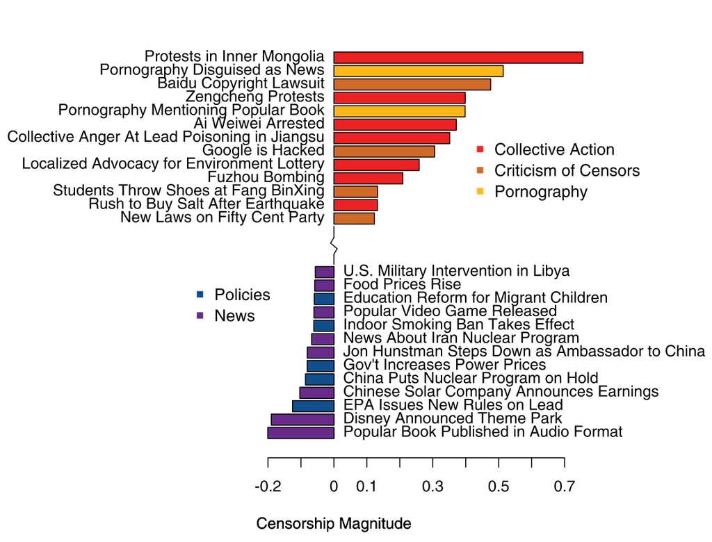

Source: King, Pan, and Roberts (2013)

## Manterrupting in the German Bundestag

RQ: are women more often interrupted than men in politics? Och (2020)

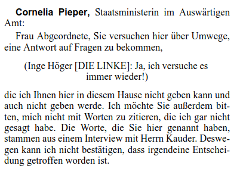

## Manterrupting in the German Bundestag

RQ: are women more often interrupted than men in politics? Och (2020)

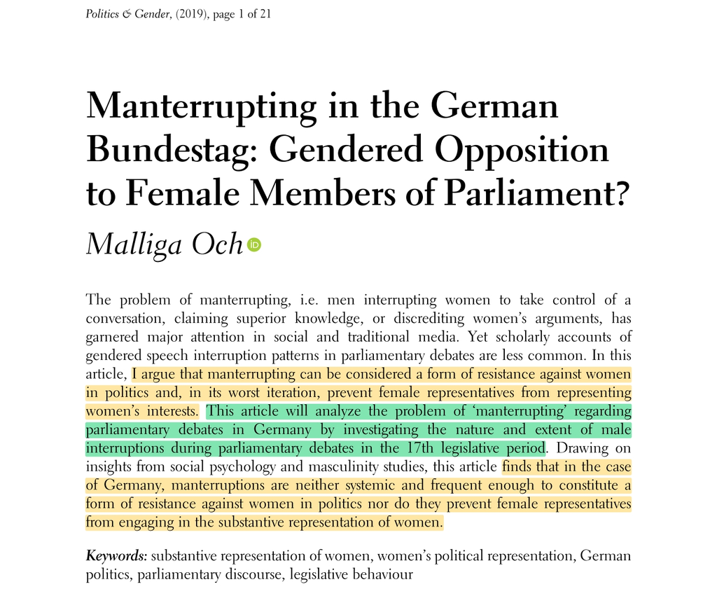

# References

Atteveldt, Wouter van, Damian Trilling, and Carlos Arcíla. 2021. *Computational Analysis of Communication: A Practical Introduction to the Analysis of Texts, Networks, and Images with Code Examples in Python and R*. Hoboken, NJ: John Wiley & Sons. https://cssbook.net.

Bail, Chris. 2022. *Breaking the Social Media Prism: How to Make Our Platforms Less Polarizing*. Princeton University Press.

Centola, Damon. 2018. “How Behavior Spreads: The Science of Complex Contagions.” *Princeton University Press*, no. 588: 1–10.

Edelmann, Achim, Tom Wolff, Danielle Montagne, and Christopher A Bail. 2020. “Computational Social Science and Sociology.” *Annual Review of Sociology* 46 (1): 61–81.

Grigoropoulou, Nikolitsa, and Mario Small. 2022. “The Data Revolution in Social Science Needs Qualitative Research.” *Nature Human Behaviour* 6 (7): 904–6.

Grimmer, Justin, Margaret Roberts, and Brandon Stewart. 2022. *Text as Data: A New Framework for Machine Learning and the Social Sciences*. Princeton University Press.

King, Gary, Jennifer Pan, and Margaret E. Roberts. 2013. “How Censorship in China Allows Government Criticism but Silences Collective Expression.” *American Political Science Review* 107 (2 (May)): 1–18.

———. 2014. “Reverse-Engineering Censorship in China: Randomized Experimentation and Participant Observation.” *Science* 345 (6199): 1–10. http://www.sciencemag.org/content/345/6199/1251722.abstract.

Kitts, James, Helene Grogan, and Kevin Lewis. 2023. “Social Networks and Computational Social Science.” In *The SAGE Handbook of Social Network Analysis*, edited by John McLevey, John Scott, and Peter J. Carrington. Sage.

McElreath, Richard. 2018. *Statistical Rethinking: A Bayesian Course with Examples in r and Stan*. Chapman; Hall/CRC.

McLevey, John. 2022. *Doing Computational Social Science: A Practical Introduction*. Sage.

McLevey, John, Pierson Browne, and Tyler Crick. 2021. “Reproducibility and Principled Data Processing.” In *Handbook of Computational Social Science, Volume 2*, 108–24. Routledge.

Nelson, Laura K. 2020. “Computational Grounded Theory: A Methodological Framework.” *Sociological Methods & Research* 49 (1): 3–42.

O’Neil, Cathy. 2017. *Weapons of Math Destruction: How Big Data Increases Inequality and Threatens Democracy*. Crown.

Och, Malliga. 2020. “Manterrupting in the German Bundestag: Gendered Opposition to Female Members of Parliament?” *Politics & Gender* 16 (2): 388–408. https://doi.org/10.1017/S1743923X19000126.

Robinson, David. 2016. “Text Analysis of Trump’s Tweets Confirms He Writes Only the (Angrier) Android Half.” *Variance Explained*. http://varianceexplained.org/r/trump-tweets/.

Salganik, Matthew. 2019. *Bit by Bit: Social Research in the Digital Age*. Princeton University Press.

Smaldino, Paul. 2023. *Modeling Social Behavior: Mathematical and Agent-Based Models of Social Dynamics and Cultural Evolution*. Princeton University Press.

Wickham, Hadley, Mine Çetinkaya-Rundel, and Garrett Grolemund. 2023. *R for Data Science: Import, Tidy, Transform, Visualize, and Model Data*. 2nd edition. Beijing Boston Farnham Sebastopol Tokyo: O’Reilly.